# Tutorial 3 - Visualise data with `ggplot2`

Author: Matthew J. Crossley

Last update: 29 March, 2026

```r
# load libraries

library(data.table)
library(ggplot2)

# clean work space

rm(list = ls())

# init colorscheme

COL <- c("#2271B2", "#E69F00", "#D55E00")
names(COL) <- c("blue", "orange", "red")
theme_set(
  theme_minimal(base_size = 13) +
    theme(
      panel.grid.minor = element_blank(),
      strip.text = element_text(face = "bold"),
      legend.position = "bottom"
    )
)
update_geom_defaults("point", list(size = 2))
update_geom_defaults("line", list(linewidth = 0.8))
```

## Learning objectives

- Learn how to wrange real data into a `data.table` and plot it using `ggplot`.
- Get lots of hands-on practice with `R` and `data.table` and `ggplot`.
- In particular, practice using the following functions:
  - `ggplot()`
  - `geom_point()`
  - `geom_line()`
  - `geom_bar()`
  - `geom_hist()`
  - `geom_violin()`
  - `geom_boxplot()`

## 1.

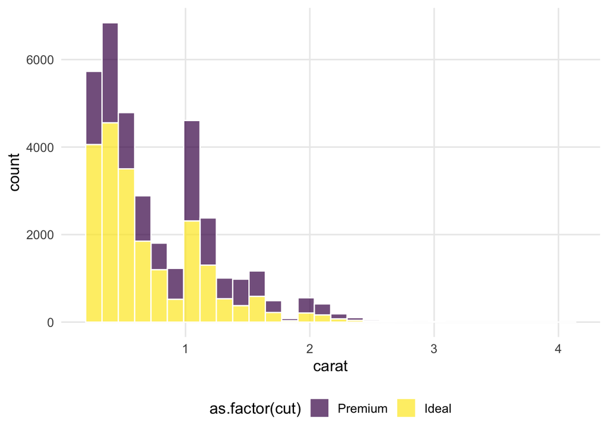

```
##      cut mean_carat range_carat
##    <ord>      <num>       <num>
## 1: Ideal   0.702837         3.3
```

## 2.

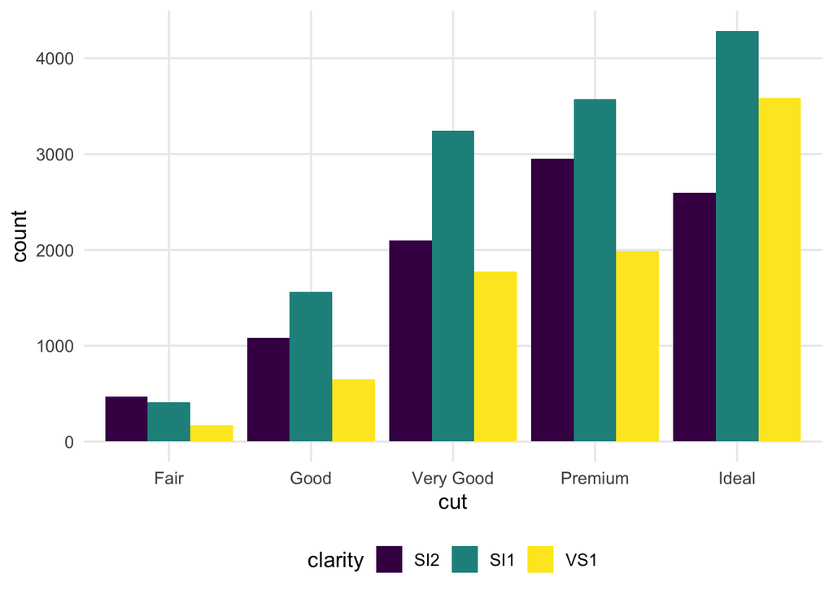

```
##           cut clarity     N
##         <ord>   <ord> <int>
##  1:     Ideal     SI2  2598
##  2:   Premium     SI1  3575
##  3:      Good     VS1   648
##  4:   Premium     VS2  3357
##  5:      Good     SI2  1081
##  6: Very Good    VVS2  1235
##  7: Very Good    VVS1   789
##  8: Very Good     SI1  3240
##  9:      Fair     VS2   261
## 10: Very Good     VS1  1775
## 11:      Good     SI1  1560
## 12:     Ideal     VS1  3589
## 13:   Premium     SI2  2949
```

[output cut: 28 more lines]

## 3.

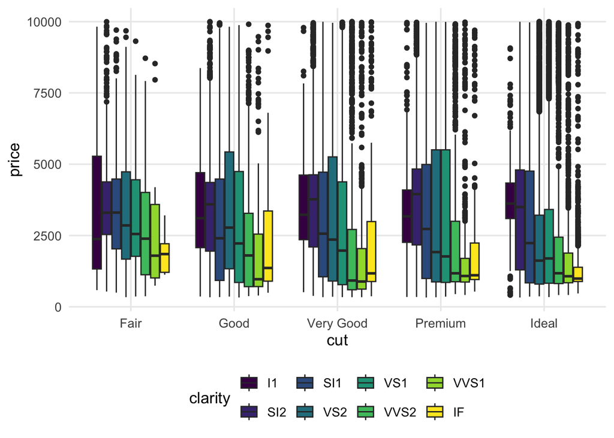

```
##           cut clarity median_cty range_cty
##         <ord>   <ord>      <num>     <int>
##  1:     Ideal     SI2      599.0       670
##  2:   Premium     SI1      709.0       672
##  3:      Good     VS1      616.0       662
##  4:   Premium     VS2      734.0       665
##  5:      Good     SI2      593.0       662
##  6: Very Good    VVS2      605.0       652
##  7: Very Good    VVS1      642.0       659
##  8: Very Good     SI1      660.5       656
##  9:      Fair     VS2      813.0       659
## 10: Very Good     VS1      640.0       660
## 11:      Good     SI1      606.0       655
## 12:     Ideal     VS1      716.0       659
## 13:   Premium     SI2      631.0       652
```

[output cut: 27 more lines]

## 4.

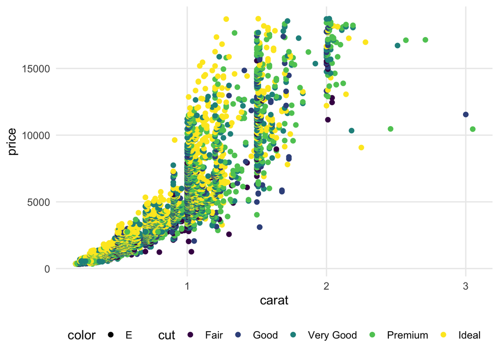

## T-maze learning example

In Tutorial 2 you performed a simple analysis of data from a T-maze learning experiment. We will now use the same dataset again, but this time focus on visualisation.

For this example, use the local file in the tutorial folder. If your working directory is set correctly, the file will load from `data/`.

**a.** Repeat the data processing and analysis steps performed in Tutorial 2:

- Load the data using `fread`
- (For now) keep only Experiment 1
- Keep only the columns `cage_context`, `rat_id`, and `maze_run_time`
- Compute mean `maze_run_time` grouped by `cage_context` and `rat_id`
- Store the result in a `data.table` with columns

```
cage_context | rat_id | maze_run_time_mean
```

You should already know how to do this from the previous tutorial. If not, revisit Tutorial 2 before continuing.

For the remainder of this tutorial, assume this processed data exists and is named:

```r
ans_8d
```

**b.** A good first step in any analysis is to examine the distribution of the dependent variable.

Create a histogram of `maze_run_time_mean`.

```r
library(ggplot2)

ggplot(ans_8d, aes(x = maze_run_time_mean)) +
  geom_histogram(bins = 30, fill = COL[1], colour = "white")
```

Questions to consider:

- Is the distribution symmetric?
- Are there extreme values?
- Does the scale – i.e., the range of `maze_run_time_mean` values – make sense given the task?
- Are there outliers (i.e., observed `maze_run_time_mean` values that do not reflect a genuine running or choice process but likely instead reflect some other process such as distraction or recording error)?

**c.** We are usually interested in whether conditions differ.

Create a boxplot comparing mean maze-run time across contexts.

```r
ggplot(ans_8d, aes(x = cage_context, y = maze_run_time_mean)) +
  geom_boxplot(fill = COL[1], outlier.shape = NA)
```

Add points showing individual rats.

```r
ggplot(ans_8d, aes(x = cage_context, y = maze_run_time_mean)) +
  geom_boxplot(fill = COL[1], outlier.shape = NA) +
  geom_jitter(width = 0.1, alpha = 0.4)
```

Questions to consider:

- Do the contexts look different? Do they have different medians? Different variability? Different distribution shapes?
- Is there large variability between rats?
- Are differences consistent or driven by outliers?

**d.** Finally, visualise the context means using a bar plot with error bars showing the standard error of the mean. Note that the standard error of the mean is one very common way to quantify variability in a sample. This will soon be covered extensively in lectures. For now, the key point to notice is that where a box plot or histogram explicitly shows the distribution of data, a bar plot with error bars instead shows only a summary of the data (i.e., the mean and standard error of the mean). The bar plot is also far more common in published papers. Is this for better or for worse?

First, create a `data.table` containing the mean and standard error of `maze_run_time_mean` for each `cage_context`. Name the columns `mean_run` and `se_run`.

```r
ans_summary <- ans_8d[
  , .(mean_run = mean(maze_run_time_mean),
      se_run = sd(maze_run_time_mean) / sqrt(.N)),
  by = cage_context
]
```

Next, create the bar plot.

```r
ggplot(ans_summary, aes(x = cage_context, y = mean_run)) +
  geom_bar(stat = "identity", fill = COL[1]) +
  geom_errorbar(
    aes(ymin = mean_run - se_run,
        ymax = mean_run + se_run),
    width = 0.05
  )
```

Questions to consider:

- Do the contexts look different? Do they have different means?
- Are any differences in means you might see large relative to the variability in the data (i.e., the size of the error bars)?